# EasyVisa Project

### Desicion Tree with Parameters

```python
Dtree_estimator =DecisionTreeClassifier(random_state=1,class_weight="balanced")
Dtree_parameters={
    "max_depth":np.arange(2,10,2),
    "min_samples_split":[3,6,9,10,15],
    "min_samples_leaf":[1,3,5,7,8,9],
    "min_impurity_decrease":[0.001,0.01,0.1],
    "max_leaf_nodes":[7,10,12,18]
}
ssc_score=metrics.make_scorer(metrics.f1_score)
grid_obj= GridSearchCV(Dtree_estimator,Dtree_parameters,scoring=ssc_score,cv=5,n_jobs=-1)
grid_obj.fit(x_train,y_train)
Dtree_estimator=grid_obj.best_estimator_
Dtree_estimator.fit(x_train,y_train)
```

```
DecisionTreeClassifier(class_weight='balanced', max_depth=4, max_leaf_nodes=7,
                       min_impurity_decrease=0.001, min_samples_split=3,
                       random_state=1)
```

```python
Dtree_estimator_train=check_model_performance(Dtree_estimator,x_train,y_train)
Dtree_estimator_train
```

|  | recall | accuracy | precision | f1_score |
| --- | --- | --- | --- | --- |
| 0 | 0.779569 | 0.716641 | 0.792744 | 0.786101 |

```python
Dtree_estimator_test=check_model_performance(Dtree_estimator,x_test,y_test)
Dtree_estimator_test
```

|  | recall | accuracy | precision | f1_score |
| --- | --- | --- | --- | --- |
| 0 | 0.78237 | 0.715594 | 0.789796 | 0.786066 |

*Observation*

- The Scores for train and test are very close

*Disadvantages of the Decision Tree*

- The Decision Tree is a single Tree with weeek learner which means single tree with single Decision

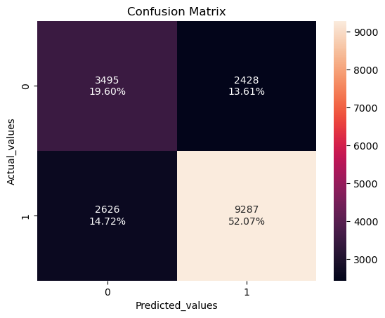

```python
checking_confution_matrix(Dtree_estimator,x_train,y_train)
```

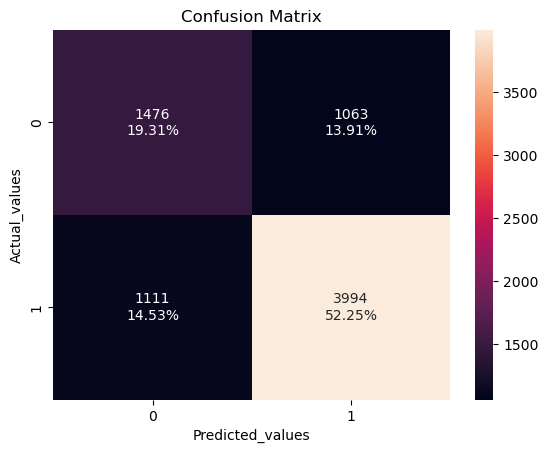

```python
checking_confution_matrix(Dtree_estimator,x_test,y_test)
```

### checking the Tree and the important features

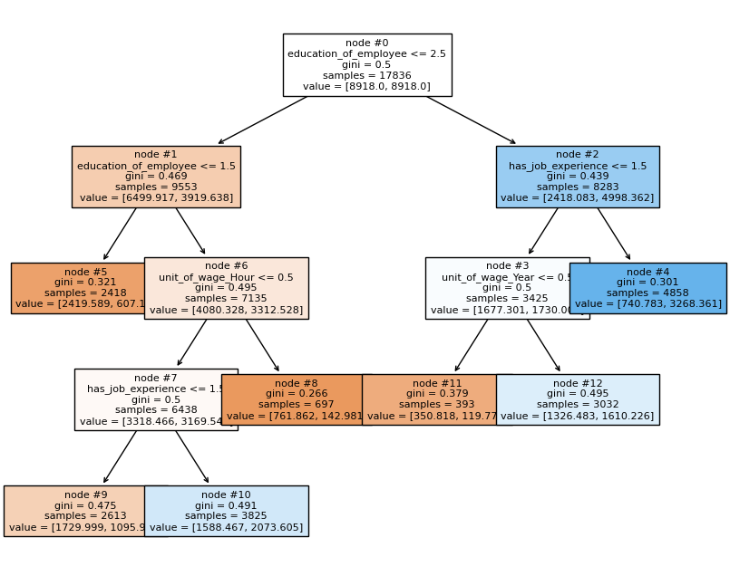

```python
feature_name=x_train.columns.to_list()
plt.figure(figsize=(10,8))
tree.plot_tree(Dtree_estimator,feature_names=feature_name,node_ids=True,impurity=True,fontsize=8,filled=True);
```

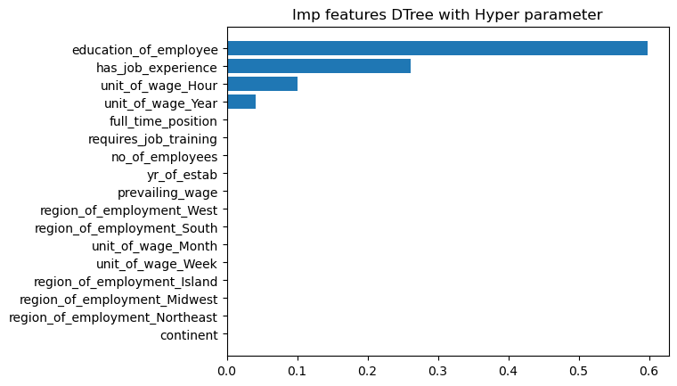

```python
feature_important=x_train.columns.to_list()
important = Dtree_estimator.feature_importances_
indecies=np.argsort(important)
plt.barh(range(len(indecies)),important[indecies]);
plt.yticks(range(len(indecies)),[feature_name[i] for i in indecies]);
plt.title("Imp features DTree with Hyper parameter");
```

*Observation*

- Overall we got good score Dtree estimator
- This is a single Tree we will go with feature model and see what are there score and will compare these

#### Bagging

- first without the hyperparameters
- second with hyperparameters

```python
bagging_model=BaggingClassifier(random_state=1,estimator=DecisionTreeClassifier(random_state=1,class_weight="balanced"))
bagging_model.fit(x_train,y_train)
```

```
BaggingClassifier(estimator=DecisionTreeClassifier(class_weight='balanced',
                                                   random_state=1),
                  random_state=1)
```

```python
bagging_model_train=check_model_performance(bagging_model,x_train,y_train)
bagging_model_train
```

|  | recall | accuracy | precision | f1_score |
| --- | --- | --- | --- | --- |
| 0 | 0.985814 | 0.984357 | 0.99072 | 0.988261 |

```python
bagging_model_test=check_model_performance(bagging_model,x_test,y_test)
bagging_model_test
```

|  | recall | accuracy | precision | f1_score |
| --- | --- | --- | --- | --- |
| 0 | 0.781587 | 0.700026 | 0.772059 | 0.776794 |

*Observation*

- The model has more nise and it is overfitted
- The scores from the test and train are not comparable

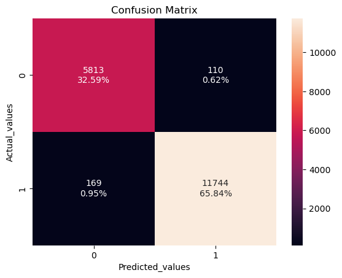

```python
checking_confution_matrix(bagging_model,x_train,y_train)
```

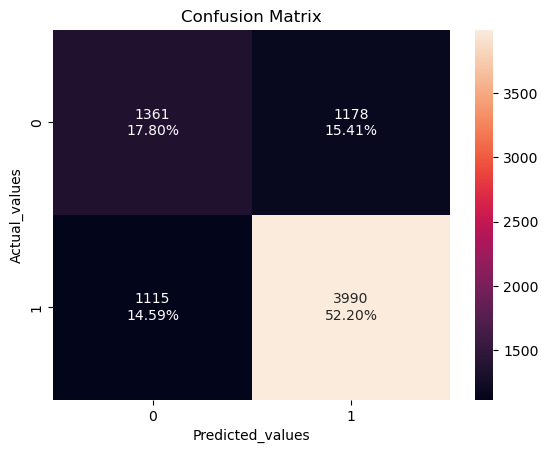

```python
checking_confution_matrix(bagging_model,x_test,y_test)
```

*Observation*

- The detection of the FP and FN are increased comparing the test and train
- TP also reduced, which is because of Noise in the data

[figure not shown]

```python
feature_name=x_train.columns.to_list()
important=bagging_model.feature_names_in_
indecies=np.argsort(important)
plt.barh(range(len(indecies)),important[indecies])
plt.yticks(range(len(indecies)),[feature_name[i] for i in indecies]);
plt.title("Imp Feature");
```